# Week 2.3 - Summary Statistics and Correlation Analysis

### Import Updated NBA Game Data

```python
import pandas as pd
NBA_Games=pd.read_csv("../../Data/Week 2/NBA_Games2.csv")
NBA_Games.head()
```

|  | CITY | TEAM_NAME | TEAM_ID | NICKNAME | STATE | YEAR_FOUNDED | SEASON_ID | TEAM_ABBREVIATION | GAME_ID | GAME_DATE | ... | AST | STL | BLK | TOV | PF | PLUS_MINUS | GM | GA | POINT_DIFF | WIN |
| --- | --- | --- | --- | --- | --- | --- | --- | --- | --- | --- | --- | --- | --- | --- | --- | --- | --- | --- | --- | --- | --- |
| 0 | Indiana | Indiana Pacers | 1610612754 | Pacers | Indiana | 1976 | 12013 | IND | 11300002 | 2013-10-05 | ... | 15 | 12 | 8 | 15 | 23 | -6.0 | 49 | 122 | 6.0 | 0 |
| 1 | Chicago | Chicago Bulls | 1610612741 | Bulls | Illinois | 1966 | 12013 | CHI | 11300002 | 2013-10-05 | ... | 20 | 5 | 10 | 23 | 25 | 6.0 | 54 | 114 | 6.0 | 1 |
| 2 | Houston | Houston Rockets | 1610612745 | Rockets | Texas | 1967 | 12013 | HOU | 11300003 | 2013-10-05 | ... | 24 | 9 | 4 | 22 | 27 | -1.0 | 76 | 128 | 1.0 | 0 |
| 3 | New Orleans | New Orleans Pelicans | 1610612740 | Pelicans | Louisiana | 2002 | 12013 | NOP | 11300003 | 2013-10-05 | ... | 17 | 12 | 4 | 15 | 32 | 1.0 | 74 | 136 | 1.0 | 1 |
| 4 | Golden State | Golden State Warriors | 1610612744 | Warriors | California | 1946 | 12013 | GSW | 11300004 | 2013-10-05 | ... | 21 | 13 | 5 | 23 | 31 | -9.0 | 60 | 137 | 9.0 | 0 |

5 rows × 36 columns

## More on Summary Statistics

### Central Tendency vs. Variation

We will compare the success rates of two-point field goals and three-point field goals to demonstrate the difference between central tendency and variation.

#### Calculate summary statistics for the percentages of two-point field goals and three-point field goals

- Two-point field goals

```python
NBA_Games['FG_PCT'].describe()
```

```
count    17779.000000
mean         0.452485
std          0.056357
min          0.217000
25%          0.414000
50%          0.452000
75%          0.489000
max          0.684000
Name: FG_PCT, dtype: float64
```

- Three-point field goals

```python
NBA_Games['FG3_PCT'].describe()
```

```
count    17779.000000
mean         0.350610
std          0.099538
min          0.000000
25%          0.286000
50%          0.350000
75%          0.417000
max          0.842000
Name: FG3_PCT, dtype: float64
```

*We can see that the average success rate of 2-point field goals is about 45.27% while the average success rate of 3-point field goals is 35.07%. That means that the overall success rate of 2-point field goals is about 10% higher than the overall success rate of 3-point field goals. The median of 2-point field goal success rate is 45.20%, while the median 3-point field goal success rate is 35.00%. This means half of the teams have 2-point field-goal success rates less than 45% and half of the teams have 3-point field goal success rate of less than 35%.*

*The standard deviation for 2-point field goal success rate is 0.056, while the standard deviation for 3-point field goal success rate is 0.09956. This means that there is a greater variation in 3-point field goals than 2-point field goals.*

### Compare the distribution of two-point field goal percentage and three-point field goal percentage using a Histogram

#### Plot two histograms side by side

*The options "sharex" and "sharey" ask if we want to restrict the same range of x and same range of y for the two histograms*

```python
NBA_Games.hist(column=['FG_PCT','FG3_PCT'], bins=20, sharex=True, sharey=True)
```

[output not shown]

```
array([[<matplotlib.axes._subplots.AxesSubplot object at 0x7f974023fef0>,
      dtype=object)
```

#### Plot two histograms in the same graph in different colors

#### We will first introduce a new library "matplotlib" that provides more useful functions to make plots.

- We will use "plot.hist" instead of "hist" to make this plot
- The option "alpha" specifies transparency, so that the two histograms would not block each other entirely (alpha=0: fully transparent; alpha=1: fully opaque)
- We can also add a title and axis labels using "plt.title," "plt.xlabel" and "plt.ylabel" commands
- We can also export the graph as a png file using the "plt.savefig" command

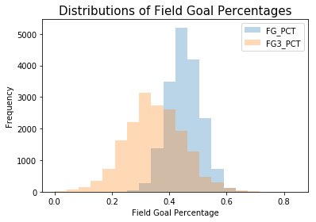

```python
import matplotlib.pyplot as plt

NBA_Games[['FG_PCT','FG3_PCT']].plot.hist(alpha=0.3, bins=20)
plt.xlabel('Field Goal Percentage')
plt.ylabel('Frequency')
plt.title("Distributions of Field Goal Percentages", fontsize=15)
plt.savefig('FG_PCT_Distributions.png')
```

#### Histogram by the result of the game using the "by" option

*We can also change the colors of the graphs using the "color" option*

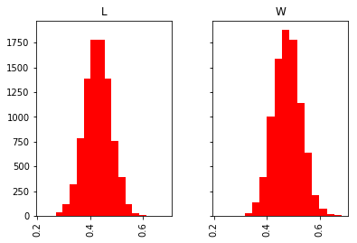

```python
NBA_Games.hist(by='WL', column='FG_PCT', color='red', bins=15, sharex=True, sharey=True)
plt.savefig('FG_PCT_WL.png')
```

## Self Test - 1

1. Calculate summary statistics for the three-point field goal percentage by the result of the game
2. Graph a histogram of the three-point field goal percentage by the result of the game and provide interpretation
- Number of bins=10, the two subgraphs should have the same x and y ranges, color is green
- Export the graph as "FG3_PCT_Distribution" in png format

```python
#Your Code Here
```

### Create time series graphs

Let's first change the data type of "GAME_DATE" from object to datetime.

```python
import datetime
NBA_Games['GAME_DATE']=pd.to_datetime(NBA_Games['GAME_DATE'])
NBA_Games['GAME_DATE'].head()
```

### Subsetting a dataset

#### The dataset we are working with contains games of different NBA teams. Let's focus on one team to produce a time series graph.

Extract Pistons' game data in the 2017-2018 season.

*Note that for date variable, we can use the >, =, < operators. When we specify the condition of the date, we need to use ""*

```python
Pistons_Games=NBA_Games[(NBA_Games.NICKNAME == 'Pistons')&(NBA_Games.SEASON_ID==22017)& (NBA_Games.GAME_DATE>='2017-10-17')]
display(Pistons_Games)
```

|  | CITY | TEAM_NAME | TEAM_ID | NICKNAME | STATE | YEAR_FOUNDED | SEASON_ID | TEAM_ABBREVIATION | GAME_ID | GAME_DATE | ... | AST | STL | BLK | TOV | PF | PLUS_MINUS | GM | GA | POINT_DIFF | WIN |
| --- | --- | --- | --- | --- | --- | --- | --- | --- | --- | --- | --- | --- | --- | --- | --- | --- | --- | --- | --- | --- | --- |
| 10919 | Detroit | Detroit Pistons | 1610612765 | Pistons | Michigan | 1948 | 22017 | DET | 21700003 | 2017-10-18 | ... | 24 | 14 | 3 | 8 | 21 | 12.0 | 61 | 134 | 12.0 | 1 |
| 10950 | Detroit | Detroit Pistons | 1610612765 | Pistons | Michigan | 1948 | 22017 | DET | 21700020 | 2017-10-20 | ... | 19 | 12 | 1 | 19 | 32 | -4.0 | 68 | 130 | 4.0 | 0 |
| 10971 | Detroit | Detroit Pistons | 1610612765 | Pistons | Michigan | 1948 | 22017 | DET | 21700030 | 2017-10-21 | ... | 21 | 5 | 2 | 12 | 25 | 4.0 | 67 | 136 | 4.0 | 1 |
| 10990 | Detroit | Detroit Pistons | 1610612765 | Pistons | Michigan | 1948 | 22017 | DET | 21700041 | 2017-10-23 | ... | 14 | 5 | 2 | 14 | 21 | -11.0 | 53 | 134 | 11.0 | 0 |
| 11019 | Detroit | Detroit Pistons | 1610612765 | Pistons | Michigan | 1948 | 22017 | DET | 21700056 | 2017-10-25 | ... | 32 | 7 | 3 | 14 | 22 | 21.0 | 74 | 143 | 21.0 | 1 |
| 11085 | Detroit | Detroit Pistons | 1610612765 | Pistons | Michigan | 1948 | 22017 | DET | 21700091 | 2017-10-29 | ... | 22 | 16 | 0 | 13 | 9 | 8.0 | 72 | 137 | 8.0 | 1 |
| 11108 | Detroit | Detroit Pistons | 1610612765 | Pistons | Michigan | 1948 | 22017 | DET | 21700104 | 2017-10-31 | ... | 21 | 7 | 3 | 12 | 11 | -20.0 | 52 | 130 | 20.0 | 0 |
| 11137 | Detroit | Detroit Pistons | 1610612765 | Pistons | Michigan | 1948 | 22017 | DET | 21700119 | 2017-11-03 | ... | 21 | 10 | 4 | 12 | 11 | 9.0 | 68 | 132 | 9.0 | 1 |
| 11161 | Detroit | Detroit Pistons | 1610612765 | Pistons | Michigan | 1948 | 22017 | DET | 21700132 | 2017-11-04 | ... | 28 | 10 | 3 | 14 | 19 | 9.0 | 68 | 125 | 9.0 | 1 |
| 11211 | Detroit | Detroit Pistons | 1610612765 | Pistons | Michigan | 1948 | 22017 | DET | 21700159 | 2017-11-08 | ... | 25 | 3 | 5 | 15 | 22 | 17.0 | 71 | 135 | 17.0 | 1 |
| 11231 | Detroit | Detroit Pistons | 1610612765 | Pistons | Michigan | 1948 | 22017 | DET | 21700169 | 2017-11-10 | ... | 23 | 7 | 5 | 17 | 18 | 7.0 | 72 | 146 | 7.0 | 1 |
| 11267 | Detroit | Detroit Pistons | 1610612765 | Pistons | Michigan | 1948 | 22017 | DET | 21700189 | 2017-11-12 | ... | 24 | 2 | 5 | 13 | 17 | 9.0 | 70 | 135 | 9.0 | 1 |
| 11304 | Detroit | Detroit Pistons | 1610612765 | Pistons | Michigan | 1948 | 22017 | DET | 21700209 | 2017-11-15 | ... | 23 | 7 | 3 | 16 | 20 | -4.0 | 65 | 145 | 4.0 | 0 |
| 11320 | Detroit | Detroit Pistons | 1610612765 | Pistons | Michigan | 1948 | 22017 | DET | 21700217 | 2017-11-17 | ... | 20 | 4 | 8 | 11 | 18 | -7.0 | 61 | 136 | 7.0 | 0 |
| 11359 | Detroit | Detroit Pistons | 1610612765 | Pistons | Michigan | 1948 | 22017 | DET | 21700238 | 2017-11-19 | ... | 25 | 10 | 2 | 19 | 21 | 3.0 | 61 | 128 | 3.0 | 1 |
| 11366 | Detroit | Detroit Pistons | 1610612765 | Pistons | Michigan | 1948 | 22017 | DET | 21700242 | 2017-11-20 | ... | 23 | 7 | 2 | 14 | 19 | -28.0 | 54 | 120 | 28.0 | 0 |
| 11425 | Detroit | Detroit Pistons | 1610612765 | Pistons | Michigan | 1948 | 22017 | DET | 21700273 | 2017-11-24 | ... | 22 | 6 | 5 | 19 | 17 | 1.0 | 60 | 130 | 1.0 | 1 |
| 11461 | Detroit | Detroit Pistons | 1610612765 | Pistons | Michigan | 1948 | 22017 | DET | 21700292 | 2017-11-27 | ... | 26 | 8 | 2 | 8 | 19 | 10.0 | 74 | 133 | 10.0 | 1 |
| 11481 | Detroit | Detroit Pistons | 1610612765 | Pistons | Michigan | 1948 | 22017 | DET | 21700303 | 2017-11-29 | ... | 31 | 11 | 6 | 19 | 22 | 24.0 | 80 | 138 | 24.0 | 1 |
| 11512 | Detroit | Detroit Pistons | 1610612765 | Pistons | Michigan | 1948 | 22017 | DET | 21700320 | 2017-12-01 | ... | 20 | 7 | 5 | 15 | 21 | -18.0 | 56 | 128 | 18.0 | 0 |
| 11530 | Detroit | Detroit Pistons | 1610612765 | Pistons | Michigan | 1948 | 22017 | DET | 21700330 | 2017-12-02 | ... | 20 | 8 | 2 | 16 | 27 | -5.0 | 69 | 141 | 5.0 | 0 |
| 11564 | Detroit | Detroit Pistons | 1610612765 | Pistons | Michigan | 1948 | 22017 | DET | 21700348 | 2017-12-04 | ... | 15 | 8 | 2 | 10 | 22 | -3.0 | 58 | 136 | 3.0 | 0 |
| 11586 | Detroit | Detroit Pistons | 1610612765 | Pistons | Michigan | 1948 | 22017 | DET | 21700359 | 2017-12-06 | ... | 20 | 5 | 0 | 11 | 20 | -4.0 | 64 | 144 | 4.0 | 0 |
| 11602 | Detroit | Detroit Pistons | 1610612765 | Pistons | Michigan | 1948 | 22017 | DET | 21700368 | 2017-12-08 | ... | 20 | 8 | 2 | 11 | 17 | -4.0 | 60 | 138 | 4.0 | 0 |
| 11636 | Detroit | Detroit Pistons | 1610612765 | Pistons | Michigan | 1948 | 22017 | DET | 21700386 | 2017-12-10 | ... | 14 | 7 | 4 | 9 | 16 | -10.0 | 53 | 136 | 10.0 | 0 |
| 11658 | Detroit | Detroit Pistons | 1610612765 | Pistons | Michigan | 1948 | 22017 | DET | 21700398 | 2017-12-12 | ... | 17 | 7 | 2 | 20 | 16 | -19.0 | 56 | 126 | 19.0 | 0 |
| 11687 | Detroit | Detroit Pistons | 1610612765 | Pistons | Michigan | 1948 | 22017 | DET | 21700413 | 2017-12-14 | ... | 26 | 10 | 3 | 15 | 23 | 15.0 | 64 | 132 | 14.0 | 1 |
| 11699 | Detroit | Detroit Pistons | 1610612765 | Pistons | Michigan | 1948 | 22017 | DET | 21700419 | 2017-12-15 | ... | 22 | 7 | 10 | 9 | 22 | 6.0 | 65 | 142 | 6.0 | 1 |
| 11733 | Detroit | Detroit Pistons | 1610612765 | Pistons | Michigan | 1948 | 22017 | DET | 21700438 | 2017-12-17 | ... | 27 | 11 | 3 | 13 | 17 | 4.0 | 72 | 139 | 4.0 | 1 |
| 11776 | Detroit | Detroit Pistons | 1610612765 | Pistons | Michigan | 1948 | 22017 | DET | 21700461 | 2017-12-20 | ... | 19 | 4 | 2 | 12 | 19 | -17.0 | 60 | 123 | 17.0 | 0 |
| ... | ... | ... | ... | ... | ... | ... | ... | ... | ... | ... | ... | ... | ... | ... | ... | ... | ... | ... | ... | ... | ... |
| 12391 | Detroit | Detroit Pistons | 1610612765 | Pistons | Michigan | 1948 | 22017 | DET | 21700790 | 2018-02-05 | ... | 36 | 7 | 4 | 14 | 14 | 20.0 | 67 | 130 | 20.0 | 1 |
| 12419 | Detroit | Detroit Pistons | 1610612765 | Pistons | Michigan | 1948 | 22017 | DET | 21700805 | 2018-02-07 | ... | 20 | 10 | 3 | 7 | 12 | 9.0 | 71 | 141 | 9.0 | 1 |
| 12472 | Detroit | Detroit Pistons | 1610612765 | Pistons | Michigan | 1948 | 22017 | DET | 21700834 | 2018-02-11 | ... | 30 | 6 | 4 | 15 | 28 | -3.0 | 77 | 149 | 3.0 | 0 |
| 12486 | Detroit | Detroit Pistons | 1610612765 | Pistons | Michigan | 1948 | 22017 | DET | 21700841 | 2018-02-12 | ... | 18 | 5 | 3 | 14 | 19 | -15.0 | 68 | 162 | 15.0 | 0 |
| 12509 | Detroit | Detroit Pistons | 1610612765 | Pistons | Michigan | 1948 | 22017 | DET | 21700853 | 2018-02-14 | ... | 26 | 3 | 5 | 16 | 18 | 6.0 | 69 | 141 | 6.0 | 1 |
| 12544 | Detroit | Detroit Pistons | 1610612765 | Pistons | Michigan | 1948 | 22017 | DET | 21700873 | 2018-02-23 | ... | 16 | 4 | 4 | 13 | 18 | -12.0 | 61 | 139 | 12.0 | 0 |
| 12580 | Detroit | Detroit Pistons | 1610612765 | Pistons | Michigan | 1948 | 22017 | DET | 21700892 | 2018-02-25 | ... | 23 | 4 | 2 | 17 | 22 | -16.0 | 56 | 117 | 16.0 | 0 |
| 12598 | Detroit | Detroit Pistons | 1610612765 | Pistons | Michigan | 1948 | 22017 | DET | 21700901 | 2018-02-26 | ... | 20 | 11 | 3 | 13 | 22 | -29.0 | 58 | 136 | 29.0 | 0 |
| 12621 | Detroit | Detroit Pistons | 1610612765 | Pistons | Michigan | 1948 | 22017 | DET | 21700913 | 2018-02-28 | ... | 26 | 9 | 0 | 9 | 20 | 23.0 | 68 | 146 | 23.0 | 1 |
| 12644 | Detroit | Detroit Pistons | 1610612765 | Pistons | Michigan | 1948 | 22017 | DET | 21700926 | 2018-03-02 | ... | 22 | 10 | 1 | 14 | 17 | -9.0 | 66 | 145 | 9.0 | 0 |
| 12666 | Detroit | Detroit Pistons | 1610612765 | Pistons | Michigan | 1948 | 22017 | DET | 21700938 | 2018-03-03 | ... | 18 | 8 | 2 | 18 | 23 | -9.0 | 59 | 134 | 9.0 | 0 |
| 12688 | Detroit | Detroit Pistons | 1610612765 | Pistons | Michigan | 1948 | 22017 | DET | 21700950 | 2018-03-05 | ... | 17 | 9 | 6 | 11 | 22 | -22.0 | 56 | 136 | 22.0 | 0 |
| 12718 | Detroit | Detroit Pistons | 1610612765 | Pistons | Michigan | 1948 | 22017 | DET | 21700966 | 2018-03-07 | ... | 27 | 2 | 7 | 16 | 23 | -2.0 | 75 | 139 | 2.0 | 0 |
| 12741 | Detroit | Detroit Pistons | 1610612765 | Pistons | Michigan | 1948 | 22017 | DET | 21700977 | 2018-03-09 | ... | 22 | 8 | 9 | 16 | 13 | 16.0 | 61 | 126 | 16.0 | 1 |
| 12806 | Detroit | Detroit Pistons | 1610612765 | Pistons | Michigan | 1948 | 22017 | DET | 21701013 | 2018-03-13 | ... | 14 | 14 | 4 | 17 | 23 | -31.0 | 49 | 124 | 31.0 | 0 |
| 12830 | Detroit | Detroit Pistons | 1610612765 | Pistons | Michigan | 1948 | 22017 | DET | 21701026 | 2018-03-15 | ... | 30 | 8 | 4 | 11 | 20 | -7.0 | 69 | 136 | 7.0 | 0 |
| 12866 | Detroit | Detroit Pistons | 1610612765 | Pistons | Michigan | 1948 | 22017 | DET | 21701045 | 2018-03-17 | ... | 17 | 6 | 2 | 12 | 16 | -13.0 | 56 | 125 | 13.0 | 0 |
| 12889 | Detroit | Detroit Pistons | 1610612765 | Pistons | Michigan | 1948 | 22017 | DET | 21701057 | 2018-03-19 | ... | 17 | 6 | 5 | 9 | 11 | 16.0 | 69 | 130 | 16.0 | 1 |
| 12899 | Detroit | Detroit Pistons | 1610612765 | Pistons | Michigan | 1948 | 22017 | DET | 21701063 | 2018-03-20 | ... | 22 | 12 | 14 | 8 | 16 | 27.0 | 72 | 149 | 27.0 | 1 |
| 12918 | Detroit | Detroit Pistons | 1610612765 | Pistons | Michigan | 1948 | 22017 | DET | 21701074 | 2018-03-22 | ... | 22 | 9 | 5 | 15 | 17 | -4.0 | 56 | 152 | 4.0 | 0 |
| 12947 | Detroit | Detroit Pistons | 1610612765 | Pistons | Michigan | 1948 | 22017 | DET | 21701089 | 2018-03-24 | ... | 33 | 6 | 7 | 13 | 11 | 22.0 | 74 | 147 | 22.0 | 1 |
| 12975 | Detroit | Detroit Pistons | 1610612765 | Pistons | Michigan | 1948 | 22017 | DET | 21701104 | 2018-03-26 | ... | 21 | 4 | 2 | 7 | 26 | 7.0 | 68 | 148 | 6.0 | 1 |
| 13011 | Detroit | Detroit Pistons | 1610612765 | Pistons | Michigan | 1948 | 22017 | DET | 21701124 | 2018-03-29 | ... | 26 | 9 | 3 | 16 | 14 | 11.0 | 62 | 125 | 11.0 | 1 |
| 13039 | Detroit | Detroit Pistons | 1610612765 | Pistons | Michigan | 1948 | 22017 | DET | 21701139 | 2018-03-31 | ... | 24 | 8 | 5 | 9 | 15 | 6.0 | 71 | 131 | 6.0 | 1 |
| 13055 | Detroit | Detroit Pistons | 1610612765 | Pistons | Michigan | 1948 | 22017 | DET | 21701148 | 2018-04-01 | ... | 17 | 9 | 3 | 9 | 16 | 12.0 | 70 | 135 | 12.0 | 1 |
| 13094 | Detroit | Detroit Pistons | 1610612765 | Pistons | Michigan | 1948 | 22017 | DET | 21701169 | 2018-04-04 | ... | 30 | 4 | 5 | 17 | 19 | -7.0 | 69 | 147 | 7.0 | 0 |
| 13117 | Detroit | Detroit Pistons | 1610612765 | Pistons | Michigan | 1948 | 22017 | DET | 21701181 | 2018-04-06 | ... | 24 | 6 | 4 | 11 | 19 | 7.0 | 67 | 139 | 7.0 | 1 |
| 13150 | Detroit | Detroit Pistons | 1610612765 | Pistons | Michigan | 1948 | 22017 | DET | 21701199 | 2018-04-08 | ... | 30 | 10 | 0 | 12 | 18 | -13.0 | 79 | 163 | 13.0 | 0 |
| 13160 | Detroit | Detroit Pistons | 1610612765 | Pistons | Michigan | 1948 | 22017 | DET | 21701204 | 2018-04-09 | ... | 22 | 7 | 2 | 3 | 11 | -10.0 | 63 | 133 | 10.0 | 0 |
| 13199 | Detroit | Detroit Pistons | 1610612765 | Pistons | Michigan | 1948 | 22017 | DET | 21701224 | 2018-04-11 | ... | 27 | 12 | 4 | 11 | 21 | 32.0 | 72 | 134 | 32.0 | 1 |

80 rows × 36 columns

#### Now we can plot the points earned by the Pistons by time.

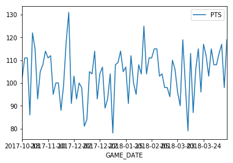

```python
Pistons_Games.plot(x='GAME_DATE', y='PTS')
plt.savefig('PISTONS_PTS_TIME.png')
```

## Self Test - 2

1. Graph Toronto Raptors' points in each game throughout the 2018-2019 seaon. (SEASON ID is 22018, and the regular season started on October 16, 2018.)
2. Export the graph as "RAPTORS_PTS_TIME" in png format

```python
#Your Code Here
```

## Correlation Analysis

### We can first detect the relationship between two variables in a scatterplot.

#### Let's use the number of assists and the number of field goals made as an example.

We can create a scatter plot using the "plot.scatter" function with the number of assists in the horizontal axis and the number of field goals made in the vertical axis.

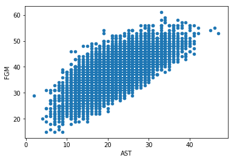

```python
NBA_Games.plot.scatter(x='AST', y='FGM')
```

#### We can use the functions in the "seaborn" library to graph the relationships between two variables

#### We will use the function "regplot" to graph the two variables. This function graphs a scatterplot as well as a regression line.

*We will learn about regression analysis more systematically in week 4*

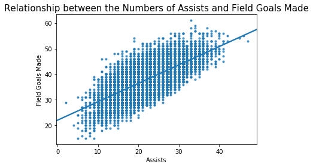

```python
import seaborn as sns
sns.regplot(x='AST', y='FGM', data=NBA_Games,  marker='.')
plt.xlabel('Assists')
plt.ylabel('Field Goals Made')
plt.title("Relationship between the Numbers of Assists and Field Goals Made", fontsize=15)
```

*As we can see from the graph, as the number of assists increase, the number of field goals made also increases. In this case, we say there is a positive relationship between the two variables, or a positive correlation.*

### Correlation Coefficient

#### We can quantify the linear correlation by a correlation coefficient. A correlation coefficient measures the joint variability of two random variables. We can calculate correlation coefficient using the "corr" function.

```python
NBA_Games['AST'].corr(NBA_Games['FGM'])
```

```
0.6965185691036626
```

*The correlation coefficient between the number of assist and field goal made is 0.70 so there is a positive correlation between the two.*

#### Let's investigate the relationship between the number of assists and the number of field goals attempted.

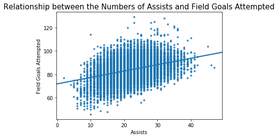

```python
sns.regplot(x='AST', y='FGA', data=NBA_Games,  marker='.')
plt.xlabel('Assists')
plt.ylabel('Field Goals Attempted')
plt.title("Relationship between the Numbers of Assists and Field Goals Attempted", fontsize=15)
```

```python
NBA_Games['AST'].corr(NBA_Games['FGA'])
```

```
0.3580107833113529
```

*Both the graph and the correlation coefficient suggest that there is only a slight positive relationship between the two.*

### We can further graph the scatter plot by group using the "hue" option.

*In this case, we can use lmplot() instead of regplot().*

- lmplot() combines regplot() and FacetGrid.
- FacetGrid produces multi-plot grid for plotting conditional relationships. Thus, FacetGrid allows us to separate the dataset into multiple panels based on specified conditions to visualize the relationship between multiple variables.

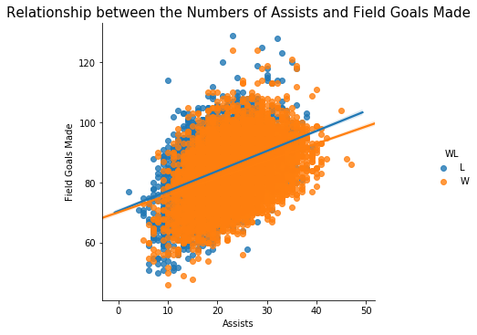

```python
sns.lmplot(x='AST', y='FGA', hue='WL', data=NBA_Games)
plt.xlabel('Assists')
plt.ylabel('Field Goals Made')
plt.title("Relationship between the Numbers of Assists and Field Goals Made", fontsize=15)
```

### We can also find correlation coefficients for all the numerical variables.

We will specify the method to be pearson.

```python
NBA_Games.corr(method='pearson')
```

|  | TEAM_ID | YEAR_FOUNDED | SEASON_ID | GAME_ID | MIN | PTS | FGM | FGA | FG_PCT | FG3M | ... | AST | STL | BLK | TOV | PF | PLUS_MINUS | GM | GA | POINT_DIFF | WIN |
| --- | --- | --- | --- | --- | --- | --- | --- | --- | --- | --- | --- | --- | --- | --- | --- | --- | --- | --- | --- | --- | --- |
| TEAM_ID | 1.000000 | 0.159684 | -0.028499 | -0.004395 | 0.009351 | -0.039739 | -0.022654 | -0.015416 | -0.014638 | -0.113377 | ... | -0.099493 | -0.012723 | 0.001869 | -0.029375 | 0.009959 | -0.000230 | -0.045124 | -0.071552 | -0.006167 | -0.005021 |
| YEAR_FOUNDED | 0.159684 | 1.000000 | -0.007430 | 0.001668 | 0.004383 | -0.023968 | -0.025650 | -0.057025 | 0.016595 | -0.080916 | ... | -0.071955 | -0.025948 | 0.005549 | -0.092220 | -0.044801 | 0.019938 | -0.019812 | -0.079766 | -0.025487 | 0.018298 |
| SEASON_ID | -0.028499 | -0.007430 | 1.000000 | -0.017029 | 0.038428 | 0.001082 | -0.001468 | -0.011046 | 0.008601 | 0.029134 | ... | -0.037363 | -0.071756 | 0.001645 | -0.148397 | -0.033619 | -0.000098 | 0.002516 | -0.002400 | 0.034086 | 0.000007 |
| GAME_ID | -0.004395 | 0.001668 | -0.017029 | 1.000000 | -0.795786 | -0.385555 | -0.397515 | -0.425308 | -0.159096 | -0.133298 | ... | -0.357418 | 0.015759 | -0.031720 | 0.088664 | 0.113199 | -0.001348 | -0.328031 | -0.309005 | -0.041346 | -0.000216 |
| MIN | 0.009351 | 0.004383 | 0.038428 | -0.795786 | 1.000000 | 0.426840 | 0.419529 | 0.519493 | 0.107260 | 0.147632 | ... | 0.327648 | 0.009281 | 0.062864 | -0.037703 | 0.004222 | 0.002040 | 0.375849 | 0.418456 | -0.071876 | 0.000905 |
| PTS | -0.039739 | -0.023968 | 0.001082 | -0.385555 | 0.426840 | 1.000000 | 0.867683 | 0.450413 | 0.687911 | 0.551357 | ... | 0.645715 | 0.087527 | 0.076797 | -0.135769 | 0.079831 | 0.510800 | 0.951691 | 0.573085 | -0.004586 | 0.411991 |
| FGM | -0.022654 | -0.025650 | -0.001468 | -0.397515 | 0.419529 | 0.867683 | 1.000000 | 0.567172 | 0.752900 | 0.386788 | ... | 0.696519 | 0.075070 | 0.077765 | -0.173950 | -0.021522 | 0.455110 | 0.673122 | 0.345795 | 0.030095 | 0.345159 |
| FGA | -0.015416 | -0.057025 | -0.011046 | -0.425308 | 0.519493 | 0.450413 | 0.567172 | 1.000000 | -0.108339 | 0.210054 | ... | 0.358011 | 0.097593 | 0.052087 | -0.290790 | -0.004342 | 0.010156 | 0.319723 | 0.686780 | -0.008601 | -0.034392 |
| FG_PCT | -0.014638 | 0.016595 | 0.008601 | -0.159096 | 0.107260 | 0.687911 | 0.752900 | -0.108339 | 1.000000 | 0.297176 | ... | 0.553814 | 0.010608 | 0.051534 | 0.021360 | -0.024364 | 0.537798 | 0.558314 | -0.126521 | 0.039784 | 0.442808 |
| FG3M | -0.113377 | -0.080916 | 0.029134 | -0.133298 | 0.147632 | 0.551357 | 0.386788 | 0.210054 | 0.297176 | 1.000000 | ... | 0.455304 | 0.001757 | 0.014574 | -0.035839 | 0.009143 | 0.314799 | 0.581310 | 0.475984 | 0.041768 | 0.229511 |
| FG3A | -0.141702 | -0.105705 | 0.033934 | -0.091262 | 0.134381 | 0.330048 | 0.189092 | 0.352338 | -0.054533 | 0.758875 | ... | 0.270667 | 0.032203 | 0.011039 | -0.046820 | 0.030102 | 0.070838 | 0.374195 | 0.708340 | 0.021652 | 0.017115 |
| FG3_PCT | -0.016194 | -0.004177 | 0.007463 | -0.107037 | 0.081386 | 0.461644 | 0.369696 | -0.060742 | 0.498434 | 0.666344 | ... | 0.383332 | -0.029102 | 0.007817 | -0.004600 | -0.019259 | 0.385708 | 0.458407 | -0.046256 | 0.025043 | 0.319531 |
| FTM | 0.022796 | 0.043878 | -0.012781 | -0.042625 | 0.085556 | 0.289037 | -0.154558 | -0.175785 | -0.042105 | -0.098478 | ... | -0.129175 | 0.055602 | 0.018518 | 0.041629 | 0.214236 | 0.104961 | 0.525449 | 0.350053 | -0.092309 | 0.140648 |
| FTA | 0.027864 | 0.022341 | -0.026548 | -0.008893 | 0.063729 | 0.228967 | -0.179234 | -0.192247 | -0.059235 | -0.118562 | ... | -0.152455 | 0.071859 | 0.022939 | 0.062648 | 0.242506 | 0.063806 | 0.451328 | 0.375464 | -0.091060 | 0.111220 |
| FT_PCT | -0.012245 | 0.052001 | 0.025631 | -0.084707 | 0.059872 | 0.184674 | 0.036479 | 0.008677 | 0.038437 | 0.032590 | ... | 0.036919 | -0.023640 | -0.000505 | -0.041403 | -0.033095 | 0.120944 | 0.252196 | -0.005780 | -0.018274 | 0.096087 |
| OREB | 0.036501 | -0.034884 | -0.007488 | -0.021565 | 0.081987 | 0.015096 | 0.024390 | 0.457630 | -0.331032 | -0.107732 | ... | -0.083991 | 0.024804 | 0.003202 | 0.028897 | 0.051179 | -0.015132 | 0.007392 | 0.338888 | -0.041755 | -0.033558 |
| DREB | -0.001342 | -0.034135 | -0.030477 | -0.244214 | 0.295010 | 0.249265 | 0.228756 | 0.267987 | 0.065561 | 0.138558 | ... | 0.212748 | -0.159332 | 0.217745 | 0.098718 | -0.047755 | 0.401344 | 0.229519 | 0.271185 | 0.013246 | 0.330675 |
| REB | 0.019690 | -0.048245 | -0.029591 | -0.215206 | 0.291852 | 0.215716 | 0.203973 | 0.483507 | -0.134207 | 0.053721 | ... | 0.128897 | -0.118250 | 0.182747 | 0.098495 | -0.010509 | 0.324848 | 0.194918 | 0.418484 | -0.012793 | 0.255627 |
| AST | -0.099493 | -0.071955 | -0.037363 | -0.357418 | 0.327648 | 0.645715 | 0.696519 | 0.358011 | 0.553814 | 0.455304 | ... | 1.000000 | 0.075061 | 0.090847 | -0.069542 | -0.058044 | 0.377541 | 0.530368 | 0.279670 | 0.083065 | 0.288407 |
| STL | -0.012723 | -0.025948 | -0.071756 | 0.015759 | 0.009281 | 0.087527 | 0.075070 | 0.097593 | 0.010608 | 0.001757 | ... | 0.075061 | 1.000000 | 0.001597 | 0.129524 | 0.047723 | 0.162410 | 0.083840 | 0.114712 | 0.040090 | 0.134071 |
| BLK | 0.001869 | 0.005549 | 0.001645 | -0.031720 | 0.062864 | 0.076797 | 0.077765 | 0.052087 | 0.051534 | 0.014574 | ... | 0.090847 | 0.001597 | 1.000000 | 0.041792 | 0.010336 | 0.179794 | 0.066213 | 0.049553 | -0.030528 | 0.164220 |
| TOV | -0.029375 | -0.092220 | -0.148397 | 0.088664 | -0.037703 | -0.135769 | -0.173950 | -0.290790 | 0.021360 | -0.035839 | ... | -0.069542 | 0.129524 | 0.041792 | 1.000000 | 0.219995 | -0.128621 | -0.094530 | -0.165697 | 0.016139 | -0.110268 |
| PF | 0.009959 | -0.044801 | -0.033619 | 0.113199 | 0.004222 | 0.079831 | -0.021522 | -0.004342 | -0.024364 | 0.009143 | ... | -0.058044 | 0.047723 | 0.010336 | 0.219995 | 1.000000 | -0.052164 | 0.132052 | 0.144639 | -0.110580 | -0.103020 |
| PLUS_MINUS | -0.000230 | 0.019938 | -0.000098 | -0.001348 | 0.002040 | 0.510800 | 0.455110 | 0.010156 | 0.537798 | 0.314799 | ... | 0.377541 | 0.162410 | 0.179794 | -0.128621 | -0.052164 | 1.000000 | 0.478775 | 0.079163 | 0.001901 | 0.805278 |
| GM | -0.045124 | -0.019812 | 0.002516 | -0.328031 | 0.375849 | 0.951691 | 0.673122 | 0.319723 | 0.558314 | 0.581310 | ... | 0.530368 | 0.083840 | 0.066213 | -0.094530 | 0.132052 | 0.478775 | 1.000000 | 0.638953 | -0.025411 | 0.399696 |
| GA | -0.071552 | -0.079766 | -0.002400 | -0.309005 | 0.418456 | 0.573085 | 0.345795 | 0.686780 | -0.126521 | 0.475984 | ... | 0.279670 | 0.114712 | 0.049553 | -0.165697 | 0.144639 | 0.079163 | 0.638953 | 1.000000 | -0.042439 | 0.048762 |
| POINT_DIFF | -0.006167 | -0.025487 | 0.034086 | -0.041346 | -0.071876 | -0.004586 | 0.030095 | -0.008601 | 0.039784 | 0.041768 | ... | 0.083065 | 0.040090 | -0.030528 | 0.016139 | -0.110580 | 0.001901 | -0.025411 | -0.042439 | 1.000000 | 0.001514 |
| WIN | -0.005021 | 0.018298 | 0.000007 | -0.000216 | 0.000905 | 0.411991 | 0.345159 | -0.034392 | 0.442808 | 0.229511 | ... | 0.288407 | 0.134071 | 0.164220 | -0.110268 | -0.103020 | 0.805278 | 0.399696 | 0.048762 | 0.001514 | 1.000000 |

28 rows × 28 columns